# Linear Modelling

Vishruth Reddy

2022-12-12

```r
library(tidyverse)
df <- readr::read_csv("fall2022_finalproject.csv", col_names = TRUE)
df %>% glimpse()
```

```
## Rows: 1,252
## Columns: 11
## $ x1     <dbl> 0.025878, 0.030768, 0.019325, 0.306212, 0.031296, 0.031073, 0.0…
## $ x2     <dbl> 0.255934, 0.261575, 0.020877, 0.033379, 0.259342, 0.027119, 0.0…
## $ x3     <dbl> 0.492830, 0.498460, 0.258360, 0.255385, 0.264387, 0.260915, 0.0…
## $ x4     <dbl> 0.012770, 0.055779, 0.012424, 0.056190, 0.056594, 0.055192, 0.0…
## $ v1     <dbl> 0.275651, 0.343204, 4.998508, 5.090153, 5.031107, 9.977407, 0.2…
## $ v2     <dbl> 0.033657, 0.027082, 0.030259, 0.052342, 0.517705, 0.532436, 1.0…
## $ v3     <dbl> 1.166214, 1.260579, 1.298285, 1.322005, 1.368195, 1.298797, 1.1…
## $ v4     <dbl> 0.408402, 0.664248, 0.412870, 0.652111, 0.533701, 0.857509, 0.6…
## $ v5     <dbl> 0.525226, 2.866343, 0.409007, 0.861594, 6.451933, 0.958574, 0.2…
## $ m      <chr> "A", "A", "A", "A", "A", "A", "A", "A", "A", "A", "A", "A", "A"…
## $ output <dbl> 0.786, 0.730, 0.996, 0.326, 0.735, 0.954, 0.969, 0.986, 0.874, …
```

```r
df <- df %>%
  mutate(x5 = 1 - (x1 + x2 + x3 + x4),
         w = x2 / (x3 + x4),
         z = (x1 + x2) / (x5 + x4),
         t = v1 * v2) %>%
  glimpse()
```

```
## Rows: 1,252
## Columns: 15
## $ x1     <dbl> 0.025878, 0.030768, 0.019325, 0.306212, 0.031296, 0.031073, 0.0…
## $ x2     <dbl> 0.255934, 0.261575, 0.020877, 0.033379, 0.259342, 0.027119, 0.0…
## $ x3     <dbl> 0.492830, 0.498460, 0.258360, 0.255385, 0.264387, 0.260915, 0.0…
## $ x4     <dbl> 0.012770, 0.055779, 0.012424, 0.056190, 0.056594, 0.055192, 0.0…
## $ v1     <dbl> 0.275651, 0.343204, 4.998508, 5.090153, 5.031107, 9.977407, 0.2…
## $ v2     <dbl> 0.033657, 0.027082, 0.030259, 0.052342, 0.517705, 0.532436, 1.0…
## $ v3     <dbl> 1.166214, 1.260579, 1.298285, 1.322005, 1.368195, 1.298797, 1.1…
## $ v4     <dbl> 0.408402, 0.664248, 0.412870, 0.652111, 0.533701, 0.857509, 0.6…
## $ v5     <dbl> 0.525226, 2.866343, 0.409007, 0.861594, 6.451933, 0.958574, 0.2…
## $ m      <chr> "A", "A", "A", "A", "A", "A", "A", "A", "A", "A", "A", "A", "A"…
## $ output <dbl> 0.786, 0.730, 0.996, 0.326, 0.735, 0.954, 0.969, 0.986, 0.874, …
## $ x5     <dbl> 0.212588, 0.153418, 0.689014, 0.348834, 0.388381, 0.625701, 0.8…
## $ w      <dbl> 0.50619858, 0.47195344, 0.07709835, 0.10712990, 0.80796683, 0.0…
## $ z      <dbl> 1.25050808, 1.39745312, 0.05731369, 0.83844661, 0.65315580, 0.0…
## $ t      <dbl> 0.009277586, 0.009294651, 0.151249854, 0.266428788, 2.604629249…
```

```r
df <- df %>%
  mutate(y = boot::logit(output)) %>%
  glimpse()
```

```
## Rows: 1,252
## Columns: 16
## $ x1     <dbl> 0.025878, 0.030768, 0.019325, 0.306212, 0.031296, 0.031073, 0.0…
## $ x2     <dbl> 0.255934, 0.261575, 0.020877, 0.033379, 0.259342, 0.027119, 0.0…
## $ x3     <dbl> 0.492830, 0.498460, 0.258360, 0.255385, 0.264387, 0.260915, 0.0…
## $ x4     <dbl> 0.012770, 0.055779, 0.012424, 0.056190, 0.056594, 0.055192, 0.0…
## $ v1     <dbl> 0.275651, 0.343204, 4.998508, 5.090153, 5.031107, 9.977407, 0.2…
## $ v2     <dbl> 0.033657, 0.027082, 0.030259, 0.052342, 0.517705, 0.532436, 1.0…
## $ v3     <dbl> 1.166214, 1.260579, 1.298285, 1.322005, 1.368195, 1.298797, 1.1…
## $ v4     <dbl> 0.408402, 0.664248, 0.412870, 0.652111, 0.533701, 0.857509, 0.6…
## $ v5     <dbl> 0.525226, 2.866343, 0.409007, 0.861594, 6.451933, 0.958574, 0.2…
## $ m      <chr> "A", "A", "A", "A", "A", "A", "A", "A", "A", "A", "A", "A", "A"…
## $ output <dbl> 0.786, 0.730, 0.996, 0.326, 0.735, 0.954, 0.969, 0.986, 0.874, …
## $ x5     <dbl> 0.212588, 0.153418, 0.689014, 0.348834, 0.388381, 0.625701, 0.8…
## $ w      <dbl> 0.50619858, 0.47195344, 0.07709835, 0.10712990, 0.80796683, 0.0…
## $ z      <dbl> 1.25050808, 1.39745312, 0.05731369, 0.83844661, 0.65315580, 0.0…
## $ t      <dbl> 0.009277586, 0.009294651, 0.151249854, 0.266428788, 2.604629249…
## $ y      <dbl> 1.3009808, 0.9946226, 5.5174529, -0.7263327, 1.0201407, 3.03202…
```

```r
df <- df %>%
  mutate(outcome = ifelse(output < 0.33, 'event', 'non_event'),
         outcome = factor(outcome, levels = c("event", "non_event"))) %>%
  glimpse()
```

```
## Rows: 1,252
## Columns: 17
## $ x1      <dbl> 0.025878, 0.030768, 0.019325, 0.306212, 0.031296, 0.031073, 0.…
## $ x2      <dbl> 0.255934, 0.261575, 0.020877, 0.033379, 0.259342, 0.027119, 0.…
## $ x3      <dbl> 0.492830, 0.498460, 0.258360, 0.255385, 0.264387, 0.260915, 0.…
## $ x4      <dbl> 0.012770, 0.055779, 0.012424, 0.056190, 0.056594, 0.055192, 0.…
## $ v1      <dbl> 0.275651, 0.343204, 4.998508, 5.090153, 5.031107, 9.977407, 0.…
## $ v2      <dbl> 0.033657, 0.027082, 0.030259, 0.052342, 0.517705, 0.532436, 1.…
## $ v3      <dbl> 1.166214, 1.260579, 1.298285, 1.322005, 1.368195, 1.298797, 1.…
## $ v4      <dbl> 0.408402, 0.664248, 0.412870, 0.652111, 0.533701, 0.857509, 0.…
## $ v5      <dbl> 0.525226, 2.866343, 0.409007, 0.861594, 6.451933, 0.958574, 0.…
## $ m       <chr> "A", "A", "A", "A", "A", "A", "A", "A", "A", "A", "A", "A", "A…
## $ output  <dbl> 0.786, 0.730, 0.996, 0.326, 0.735, 0.954, 0.969, 0.986, 0.874,…
## $ x5      <dbl> 0.212588, 0.153418, 0.689014, 0.348834, 0.388381, 0.625701, 0.…
## $ w       <dbl> 0.50619858, 0.47195344, 0.07709835, 0.10712990, 0.80796683, 0.…
## $ z       <dbl> 1.25050808, 1.39745312, 0.05731369, 0.83844661, 0.65315580, 0.…
## $ t       <dbl> 0.009277586, 0.009294651, 0.151249854, 0.266428788, 2.60462924…
## $ y       <dbl> 1.3009808, 0.9946226, 5.5174529, -0.7263327, 1.0201407, 3.0320…
## $ outcome <fct> non_event, non_event, non_event, event, non_event, non_event, …
```

```r
df <- df %>%
  mutate(outcome_num = ifelse(outcome == 'event', 1, 0)) %>%
  glimpse()
```

```
## Rows: 1,252
## Columns: 18
## $ x1          <dbl> 0.025878, 0.030768, 0.019325, 0.306212, 0.031296, 0.031073…
## $ x2          <dbl> 0.255934, 0.261575, 0.020877, 0.033379, 0.259342, 0.027119…
## $ x3          <dbl> 0.492830, 0.498460, 0.258360, 0.255385, 0.264387, 0.260915…
## $ x4          <dbl> 0.012770, 0.055779, 0.012424, 0.056190, 0.056594, 0.055192…
## $ v1          <dbl> 0.275651, 0.343204, 4.998508, 5.090153, 5.031107, 9.977407…
## $ v2          <dbl> 0.033657, 0.027082, 0.030259, 0.052342, 0.517705, 0.532436…
## $ v3          <dbl> 1.166214, 1.260579, 1.298285, 1.322005, 1.368195, 1.298797…
## $ v4          <dbl> 0.408402, 0.664248, 0.412870, 0.652111, 0.533701, 0.857509…
## $ v5          <dbl> 0.525226, 2.866343, 0.409007, 0.861594, 6.451933, 0.958574…
## $ m           <chr> "A", "A", "A", "A", "A", "A", "A", "A", "A", "A", "A", "A"…
## $ output      <dbl> 0.786, 0.730, 0.996, 0.326, 0.735, 0.954, 0.969, 0.986, 0.…
## $ x5          <dbl> 0.212588, 0.153418, 0.689014, 0.348834, 0.388381, 0.625701…
## $ w           <dbl> 0.50619858, 0.47195344, 0.07709835, 0.10712990, 0.80796683…
## $ z           <dbl> 1.25050808, 1.39745312, 0.05731369, 0.83844661, 0.65315580…
## $ t           <dbl> 0.009277586, 0.009294651, 0.151249854, 0.266428788, 2.6046…
## $ y           <dbl> 1.3009808, 0.9946226, 5.5174529, -0.7263327, 1.0201407, 3.…
## $ outcome     <fct> non_event, non_event, non_event, event, non_event, non_eve…
## $ outcome_num <dbl> 0, 0, 0, 1, 0, 0, 0, 0, 0, 0, 0, 1, 0, 0, 0, 1, 1, 1, 0, 0…
```

```r
df
```

```
## # A tibble: 1,252 × 18
##        x1     x2     x3     x4    v1     v2    v3    v4      v5 m     output
##     <dbl>  <dbl>  <dbl>  <dbl> <dbl>  <dbl> <dbl> <dbl>   <dbl> <chr>  <dbl>
##  1 0.0259 0.256  0.493  0.0128 0.276 0.0337  1.17 0.408 0.525   A      0.786
##  2 0.0308 0.262  0.498  0.0558 0.343 0.0271  1.26 0.664 2.87    A      0.73
##  3 0.0193 0.0209 0.258  0.0124 5.00  0.0303  1.30 0.413 0.409   A      0.996
##  4 0.306  0.0334 0.255  0.0562 5.09  0.0523  1.32 0.652 0.862   A      0.326
##  5 0.0313 0.259  0.264  0.0566 5.03  0.518   1.37 0.534 6.45    A      0.735
##  6 0.0311 0.0271 0.261  0.0552 9.98  0.532   1.30 0.858 0.959   A      0.954
##  7 0.0244 0.0318 0.0220 0.0558 0.230 1.01    1.17 0.691 0.209   A      0.969
##  8 0.0260 0.0122 0.263  0.0571 0.242 1.01    1.25 0.607 0.00925 A      0.986
##  9 0.0207 0.266  0.499  0.0555 5.01  1.02    1.37 0.751 9.34    A      0.874
## 10 0.0195 0.0254 0.268  0.0569 0.226 0.508   5.64 0.543 1.35    A      0.995
## # … with 1,242 more rows, and 7 more variables: x5 <dbl>, w <dbl>, z <dbl>,
## #   t <dbl>, y <dbl>, outcome <fct>, outcome_num <dbl>
```

```r
mod01 <- lm( y ~ x1 + x2 + x3 + x4 + v1 + v2 + v3 + v4 + v5 + m , data = df )
```

```r
mod02 <- lm( y ~ m:(x1 + x2 + x3 + x4 + v1 + v2 + v3 + v4 + v5 ) , data = df )
```

```r
mod03 <- lm( y ~ (x1  + x2 + x3 + x4 + v1 + v2 + v3 + v4 + v5 )^2  , data = df )
```

```r
mod04 <- lm( y ~  x1 + x3 + x4  + v2 + v3 + v4 + v5 + m + w + z + t + x5  , data = df )
```

```r
mod05 <- lm( y ~ m:(x1 + x3 + x4  + v2 + v3 + v4 + v5 + m + w + z + t + x5)  , data = df )
```

```r
mod06 <- lm( y ~ (x1  + x3 + x4 + v2 + v3 + v4 + v5 + w + z + t + x5)^2  , data = df )
```

```r
mod07 <- lm( y ~ x1 + x2 + x3 + x4 , data = df )
```

```r
mod08 <- lm( y ~ v1 + v2 + v3 + v4 + v5  , data = df )
```

```r
mod09 <- lm( y ~ splines::ns(z , 3) * (x5 + w + t ) , data = df )
```

Training set RMSE

```r
rmse1 <- modelr :: rmse(mod01, df)
rmse2 <- modelr :: rmse(mod02, df)
rmse3 <- modelr :: rmse(mod03, df)
rmse4 <- modelr :: rmse(mod04, df)
rmse5 <- modelr :: rmse(mod05, df)
rmse6 <- modelr :: rmse(mod06, df)
rmse7 <- modelr :: rmse(mod07, df)
rmse8 <- modelr :: rmse(mod08, df)
rmse9 <- modelr :: rmse(mod09, df)

rmse1
```

```
## [1] 2.258486
```

```r
rmse2
```

```
## [1] 2.234195
```

```r
rmse3
```

```
## [1] 2.176498
```

```r
rmse4
```

```
## [1] 1.808582
```

```r
rmse5
```

```
## [1] 1.775723
```

```r
rmse6
```

```
## [1] 1.277901
```

```r
rmse7
```

```
## [1] 2.275503
```

```r
rmse8
```

```
## [1] 2.307992
```

```r
rmse9
```

```
## [1] 1.607607
```

Training set AIC/BIC/R squared

```r
broom :: glance(mod01)
```

```
## # A tibble: 1 × 12
##   r.squ…¹ adj.r…² sigma stati…³ p.value    df logLik   AIC   BIC devia…⁴ df.re…⁵
##     <dbl>   <dbl> <dbl>   <dbl>   <dbl> <dbl>  <dbl> <dbl> <dbl>   <dbl>   <int>
## 1  0.0459  0.0359  2.27    4.59 9.79e-8    13 -2797. 5623. 5700.   6386.    1238
## # … with 1 more variable: nobs <int>, and abbreviated variable names
## #   ¹r.squared, ²adj.r.squared, ³statistic, ⁴deviance, ⁵df.residual
```

```r
broom :: glance(mod02)
```

```
## # A tibble: 1 × 12
##   r.squ…¹ adj.r…² sigma stati…³ p.value    df logLik   AIC   BIC devia…⁴ df.re…⁵
##     <dbl>   <dbl> <dbl>   <dbl>   <dbl> <dbl>  <dbl> <dbl> <dbl>   <dbl>   <int>
## 1  0.0664  0.0315  2.28    1.90 3.51e-4    45 -2783. 5660. 5901.   6250.    1206
## # … with 1 more variable: nobs <int>, and abbreviated variable names
## #   ¹r.squared, ²adj.r.squared, ³statistic, ⁴deviance, ⁵df.residual
```

```r
broom :: glance(mod03)
```

```
## # A tibble: 1 × 12
##   r.squared adj.r.squa…¹ sigma stati…²  p.value    df logLik   AIC   BIC devia…³
##       <dbl>        <dbl> <dbl>   <dbl>    <dbl> <dbl>  <dbl> <dbl> <dbl>   <dbl>
## 1     0.114       0.0809  2.22    3.45 5.56e-13    45 -2750. 5594. 5836.   5931.
## # … with 2 more variables: df.residual <int>, nobs <int>, and abbreviated
## #   variable names ¹adj.r.squared, ²statistic, ³deviance
```

```r
broom :: glance(mod04)
```

```
## # A tibble: 1 × 12
##   r.squared adj.r.squ…¹ sigma stati…²   p.value    df logLik   AIC   BIC devia…³
##       <dbl>       <dbl> <dbl>   <dbl>     <dbl> <dbl>  <dbl> <dbl> <dbl>   <dbl>
## 1     0.388       0.381  1.82    52.3 2.24e-120    15 -2518. 5071. 5158.   4095.
## # … with 2 more variables: df.residual <int>, nobs <int>, and abbreviated
## #   variable names ¹adj.r.squared, ²statistic, ³deviance
```

```r
broom :: glance(mod05)
```

```
## # A tibble: 1 × 12
##   r.squared adj.r.squa…¹ sigma stati…²  p.value    df logLik   AIC   BIC devia…³
##       <dbl>        <dbl> <dbl>   <dbl>    <dbl> <dbl>  <dbl> <dbl> <dbl>   <dbl>
## 1     0.410        0.381  1.82    14.1 3.28e-99    59 -2495. 5113. 5426.   3948.
## # … with 2 more variables: df.residual <int>, nobs <int>, and abbreviated
## #   variable names ¹adj.r.squared, ²statistic, ³deviance
```

```r
broom :: glance(mod06)
```

```
## # A tibble: 1 × 12
##   r.squared adj.r.squ…¹ sigma stati…²   p.value    df logLik   AIC   BIC devia…³
##       <dbl>       <dbl> <dbl>   <dbl>     <dbl> <dbl>  <dbl> <dbl> <dbl>   <dbl>
## 1     0.695       0.678  1.31    42.2 6.74e-259    64 -2084. 4299. 4638.   2045.
## # … with 2 more variables: df.residual <int>, nobs <int>, and abbreviated
## #   variable names ¹adj.r.squared, ²statistic, ³deviance
```

```r
broom :: glance(mod07)
```

```
## # A tibble: 1 × 12
##   r.squ…¹ adj.r…² sigma stati…³ p.value    df logLik   AIC   BIC devia…⁴ df.re…⁵
##     <dbl>   <dbl> <dbl>   <dbl>   <dbl> <dbl>  <dbl> <dbl> <dbl>   <dbl>   <int>
## 1  0.0315  0.0284  2.28    10.1 4.41e-8     4 -2806. 5624. 5655.   6483.    1247
## # … with 1 more variable: nobs <int>, and abbreviated variable names
## #   ¹r.squared, ²adj.r.squared, ³statistic, ⁴deviance, ⁵df.residual
```

```r
broom :: glance(mod08)
```

```
## # A tibble: 1 × 12
##   r.squared adj.r.squared sigma stati…¹ p.value    df logLik   AIC   BIC devia…²
##       <dbl>         <dbl> <dbl>   <dbl>   <dbl> <dbl>  <dbl> <dbl> <dbl>   <dbl>
## 1   0.00366     -0.000339  2.31   0.915   0.470     5 -2824. 5661. 5697.   6669.
## # … with 2 more variables: df.residual <int>, nobs <int>, and abbreviated
## #   variable names ¹statistic, ²deviance
```

```r
broom :: glance(mod09)
```

```
## # A tibble: 1 × 12
##   r.squared adj.r.squ…¹ sigma stati…²   p.value    df logLik   AIC   BIC devia…³
##       <dbl>       <dbl> <dbl>   <dbl>     <dbl> <dbl>  <dbl> <dbl> <dbl>   <dbl>
## 1     0.517       0.511  1.62    88.1 8.37e-183    15 -2371. 4776. 4863.   3236.
## # … with 2 more variables: df.residual <int>, nobs <int>, and abbreviated
## #   variable names ¹adj.r.squared, ²statistic, ³deviance
```

How do the coefficient summaries compare between the top 3 models?

They are pretty much similar. The coefficients related to v1, v2, v3, v4, v5 are mostly zero while coefficients related w, z, x5 are non zero.

Which inputs seem important?

Since the coefficients of x5, w, z seem to be non-zero these inputs seem important.

What performance metric did you use to make your selection? R squared, AIC, BIC

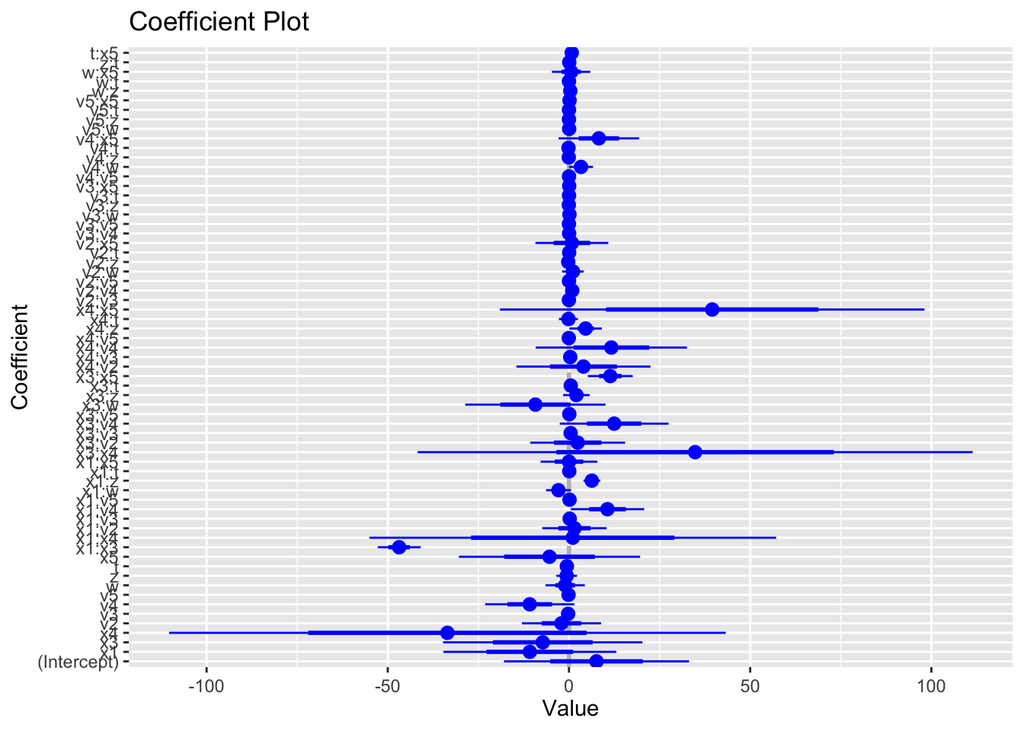

```r
coefplot::coefplot(mod06)
```

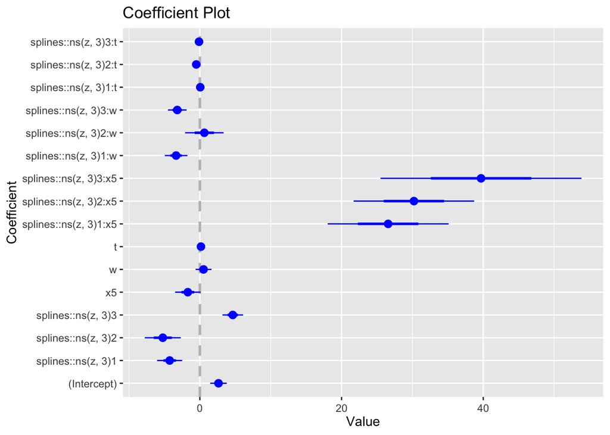

```r
coefplot::coefplot(mod09)
```

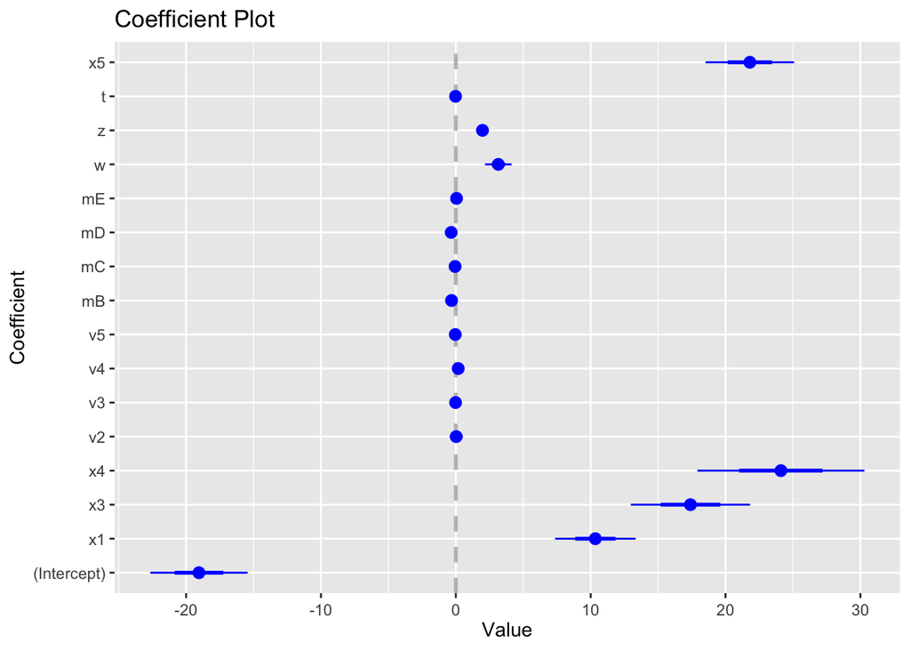

```r
coefplot::coefplot(mod04)
```

What performance metric did you use to make your selection? R squared, AIC, BIC

How do the coefficient summaries compare between the top 3 models?

Significance

Which inputs seem important?

Bayesian Linear Models

```r
bayes_lm_mod1_mat <- model.matrix( y ~ splines::ns(z , 3) * (t  + w + x5) , data = df)
dim(bayes_lm_mod1_mat)
```

```
## [1] 1252   16
```

```r
bayes_lm_mod2_mat <- model.matrix( y ~ (x1  + x3 + x4 + v2 + v3 + v4 + v5 + w + z + t + x5)^2 , data = df)
dim(bayes_lm_mod2_mat)
```

```
## [1] 1252   67
```

```r
prior_info_lm_mod1 <- list(
  yobs = df$y,
  design_matrix = bayes_lm_mod1_mat,
  mu_beta = 0 ,
  tau_beta = 2,
  sigma_rate =1
)

prior_info_lm_mod2 <- list(
  yobs = df$y,
  design_matrix = bayes_lm_mod2_mat,
  mu_beta = 0 ,
  tau_beta = 2,
  sigma_rate =1
)
```

```r
lm_logpost <- function(unknowns, my_info)
{
  length_beta <- ncol(my_info$design_matrix)

  beta_v <- unknowns[1:length_beta]

  lik_varphi <- unknowns[length_beta + 1]

  lik_sigma <- exp(lik_varphi)

  X <-  my_info$design_matrix

  mu <- as.vector(X %*% as.matrix(beta_v))

  log_lik <- sum(dnorm(x = my_info$yobs,
                       mean = mu,
                       sd = lik_sigma,
                       log = TRUE))


  log_prior_beta <-  sum(dnorm(x = beta_v,
                              mean = my_info$mu_beta,
                              sd = my_info$tau_beta,
                              log = TRUE))

   log_prior_sigma <- dexp(x = lik_sigma,
                          rate = my_info$sigma_rate,
                          log = TRUE)

  log_prior <- log_prior_beta + log_prior_sigma

  log_derive_adjust <- lik_varphi

  log_lik + log_prior + log_derive_adjust

}
```

```r
print(lm_logpost(rep (-1, ncol(bayes_lm_mod1_mat)+1), prior_info_lm_mod1))
```

```
## [1] -297878.5
```

```r
print(lm_logpost(rep (1, ncol(bayes_lm_mod1_mat)+1), prior_info_lm_mod1))
```

```
## [1] -6356.171
```

```r
print(lm_logpost(rep (-1, ncol(bayes_lm_mod2_mat)+1), prior_info_lm_mod2))
```

```
## [1] -135912208
```

```r
print(lm_logpost(rep (1, ncol(bayes_lm_mod2_mat)+1), prior_info_lm_mod2))
```

```
## [1] -2458453
```

```r
my_laplace <- function(start_guess, logpost_func, ...)
{
  fit <- optim(start_guess,
               logpost_func,
               gr = NULL,
               ...,
               method = "BFGS",
               hessian = TRUE,
               control = list(fnscale = -1, maxit = 1001))

  mode <- fit$par
  post_var_matrix <- -solve(fit$hessian)
  p <- length(mode)
  int <- p/2 * log(2*pi) + 1/2 * log(det(post_var_matrix)) + logpost_func(mode, ...)
  list(mode = mode,
       var_matrix = post_var_matrix,
       log_evidence = int,
       converge = ifelse(fit$convergence == 0,
                         "YES",
                         "NO"),
       iter_counts = as.numeric(fit$counts[1]))
}
```

```r
laplace_lm_mod1 <- my_laplace(rep (0, ncol(bayes_lm_mod1_mat)+1), lm_logpost, prior_info_lm_mod1)
laplace_lm_mod1
```

```
## $mode
##  [1]  1.00339664 -0.50672680 -0.50691073  6.86368083  0.15084505 -0.18674238
##  [7]  0.71423342  0.02043551 -0.45912613 -0.03603264 -2.46948100  2.29390346
## [13] -2.31150405  5.66578486  1.53859838  3.34349408  0.50253162
##
## $var_matrix
##                [,1]          [,2]          [,3]          [,4]          [,5]
##  [1,]  1.923891e-01 -0.0814845817 -0.3343919632 -0.0754573435 -4.964002e-03
##  [2,] -8.148458e-02  0.3952761600  0.0299533928 -0.0043688289 -3.577624e-04
##  [3,] -3.343920e-01  0.0299533928  0.7725138168  0.1786513388  1.199099e-02
##  [4,] -7.545734e-02 -0.0043688289  0.1786513388  0.2689078612  1.565854e-03
##  [5,] -4.964002e-03 -0.0003577624  0.0119909915  0.0015658540  2.980302e-03
##  [6,] -5.293048e-03 -0.0390987795  0.0487687144 -0.0258041869 -9.280883e-04
##  [7,] -2.457163e-01  0.1215706500  0.4023518214  0.1010713665 -3.596924e-03
##  [8,]  2.170200e-05 -0.0273558687  0.0067272821  0.0071860005 -2.884667e-05
```

[output cut: 72 more lines]

```r
laplace_lm_mod2 <- my_laplace(rep (0, ncol(bayes_lm_mod2_mat)+1), lm_logpost, prior_info_lm_mod2)
laplace_lm_mod2
```

```
## $mode
##  [1]  -0.428923496  -5.697004050   2.134399384   0.378928802  -0.502712680
##  [6]  -0.603224093  -0.738127621  -0.289465368  -0.044951701   1.269658840
## [11]  -0.834301591   2.650923224 -19.116074481  -0.275742306  -0.509465421
## [16]   0.374098553   0.374036510   0.159636016  -1.000194536   4.465177402
## [21]   0.181385034   4.292127035  -0.122941777   0.515065984   0.867154086
## [26]   0.103724165   0.166387957  -0.080674410  -2.095543687   0.680755075
## [31]   3.938699941   0.351637532   0.922511300   0.594798527   0.157167705
## [36]   0.184503540  -2.076045977   0.443291165   0.868608781  -0.031354878
## [41]   1.418173715  -0.047846003   0.427524362  -0.120201072   0.210061583
## [46]  -0.271578751   0.027924256  -0.005825611   0.200337170  -0.015118531
## [51]   0.012219218   0.467036070   0.008392346   0.140465885   0.047112809
## [56]  -0.198937997   0.037892157   0.070614423   0.026678269   0.008026000
## [61]   0.419381132  -0.156060107   0.019235911   0.350248905   0.075908897
## [66]  -3.517128945   0.845026482   0.301500053
```

[output cut: 977 more lines]

```r
pos_mode_lm_mod1 <- laplace_lm_mod1$mode
pos_sd_lm_mod1 <- sqrt(diag(laplace_lm_mod1$var_matrix))

pos_mode_lm_mod1
```

```
##  [1]  1.00339664 -0.50672680 -0.50691073  6.86368083  0.15084505 -0.18674238
##  [7]  0.71423342  0.02043551 -0.45912613 -0.03603264 -2.46948100  2.29390346
## [13] -2.31150405  5.66578486  1.53859838  3.34349408  0.50253162
```

```r
pos_sd_lm_mod1
```

```
##  [1] 0.43862187 0.62870992 0.87892765 0.51856327 0.05459214 0.44964779
##  [7] 0.66460245 0.11165884 0.14376100 0.09845702 0.72974229 1.06028950
## [13] 0.60523340 1.75374679 1.50292096 1.80918819 0.02013009
```

```r
pos_mode_lm_mod2 <- laplace_lm_mod2$mode
pos_sd_lm_mod2 <- sqrt(diag(laplace_lm_mod2$var_matrix))

pos_mode_lm_mod2
```

```
##  [1]  -0.428923496  -5.697004050   2.134399384   0.378928802  -0.502712680
##  [6]  -0.603224093  -0.738127621  -0.289465368  -0.044951701   1.269658840
## [11]  -0.834301591   2.650923224 -19.116074481  -0.275742306  -0.509465421
## [16]   0.374098553   0.374036510   0.159636016  -1.000194536   4.465177402
## [21]   0.181385034   4.292127035  -0.122941777   0.515065984   0.867154086
## [26]   0.103724165   0.166387957  -0.080674410  -2.095543687   0.680755075
## [31]   3.938699941   0.351637532   0.922511300   0.594798527   0.157167705
## [36]   0.184503540  -2.076045977   0.443291165   0.868608781  -0.031354878
## [41]   1.418173715  -0.047846003   0.427524362  -0.120201072   0.210061583
## [46]  -0.271578751   0.027924256  -0.005825611   0.200337170  -0.015118531
## [51]   0.012219218   0.467036070   0.008392346   0.140465885   0.047112809
## [56]  -0.198937997   0.037892157   0.070614423   0.026678269   0.008026000
## [61]   0.419381132  -0.156060107   0.019235911   0.350248905   0.075908897
## [66]  -3.517128945   0.845026482   0.301500053
```

```r
pos_sd_lm_mod2
```

```
##  [1] 1.065013517 1.482500649 1.431990207 1.850206194 1.074285568 0.353301744
##  [7] 1.064652519 0.323390043 0.928757596 0.739190568 0.464500576 1.282679059
## [13] 1.576338947 1.956149416 1.220140059 0.295941512 1.235057752 0.268982285
## [19] 1.124461432 0.662318871 0.394439440 1.643657820 1.962695534 1.372607790
## [25] 0.428601977 1.399291418 0.395017492 1.694362194 0.953232549 0.560512126
## [31] 1.601196948 1.884599828 0.621560027 1.884523012 0.563432020 1.860114761
## [37] 1.445081253 0.858229182 1.936616591 0.062153229 0.767001060 0.053816016
## [43] 0.630959868 0.214193428 0.074177284 1.274914526 0.068656264 0.004602596
## [49] 0.101584419 0.021864041 0.008344878 0.327921357 0.052574527 0.634207052
## [55] 0.198964940 0.110983953 1.256725902 0.091282678 0.016821259 0.007033588
## [61] 0.300633634 0.280219856 0.139967254 1.251685066 0.031940208 1.329402946
## [67] 0.427914451 0.020946279
```

Evaluation

Bayes factor to compare 2 models. laplace_lm_mod2 is better

```r
exp(laplace_lm_mod2$log_evidence - laplace_lm_mod1$log_evidence )
```

```
## [1] 1.212849e+37
```

```r
viz_post_coefs <- function(post_means, post_sds, xnames)
{
  tibble::tibble(
    mu = post_means,
    sd = post_sds,
    x = xnames
  ) %>%
    mutate(x = factor(x, levels = xnames)) %>%
    ggplot(mapping = aes(x = x)) +
    geom_hline(yintercept = 0, color = 'grey', linetype = 'dashed') +
    geom_point(mapping = aes(y = mu)) +
    geom_linerange(mapping = aes(ymin = mu - 2 * sd,
                                 ymax = mu + 2 * sd,
                                 group = x)) +
    labs(x = 'feature', y = 'coefficient value') +
    coord_flip() +
    theme_bw()
}
```

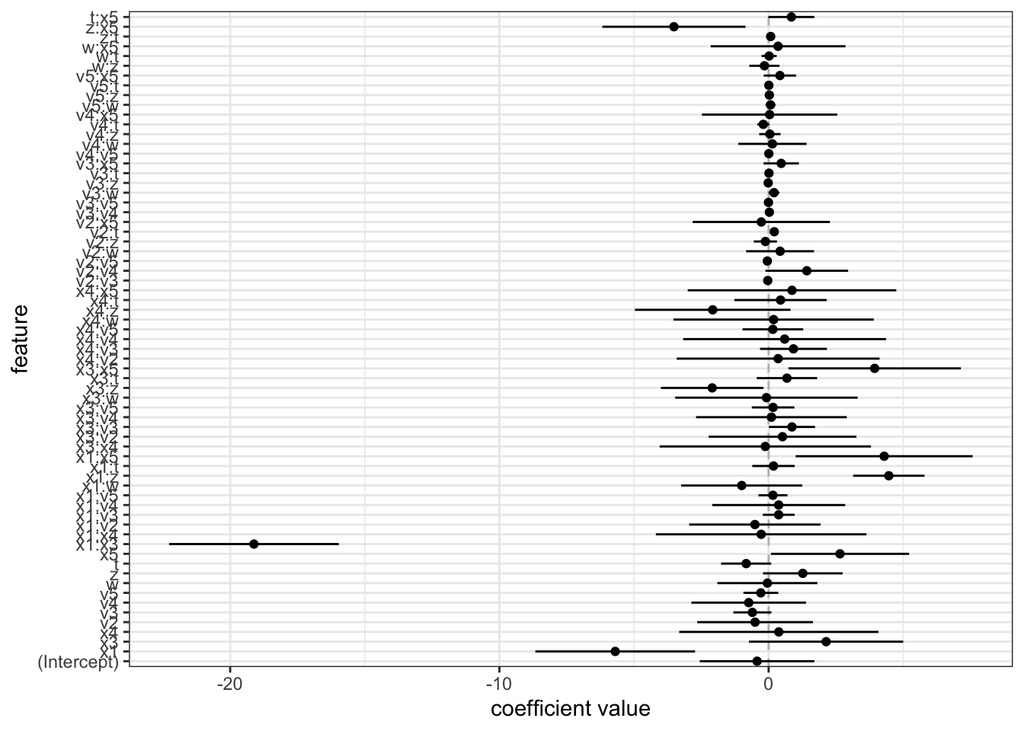

```r
viz_post_coefs(laplace_lm_mod2$mode[1:ncol(bayes_lm_mod2_mat)], sqrt(diag(laplace_lm_mod2$var_matrix))[1:ncol(bayes_lm_mod2_mat)], colnames(bayes_lm_mod2_mat))
```

#best model using bayes factor. #best model using AIC/BIC linear models

Linear Models Predictions

For non bayesian linear model

```r
viz_grid_lm <- expand.grid(x1 = seq(from=min(df$x1),to=max(df$x1),length.out=101),
                        x3 = seq(from=min(df$x3),to=max(df$x3),length.out=6),
                        x4 = median(df$x4),
                        v2 = median(df$v2),
                        v3 = median(df$v3),
                        v4 = median(df$v4),
                        v5 = median(df$v5),
                        w = median(df$w),
                        z = median(df$z),
                        t = median(df$t),
                        x5 = median(df$x5),
                        KEEP.OUT.ATTRS = FALSE,
                        stringsAsFactors = FALSE) %>%
  as.data.frame() %>% tibble::as_tibble()
```

```r
tidy_predict <- function(mod, xnew)
{
  pred_df <- predict(mod, xnew, interval = "confidence") %>%
    as.data.frame() %>% tibble::as_tibble() %>%
    dplyr::select(pred = fit, ci_lwr = lwr, ci_upr = upr) %>%
    bind_cols(predict(mod, xnew, interval = 'prediction') %>%
                as.data.frame() %>% tibble::as_tibble() %>%
                dplyr::select(pred_lwr = lwr, pred_upr = upr))

  xnew %>% bind_cols(pred_df)
}
```

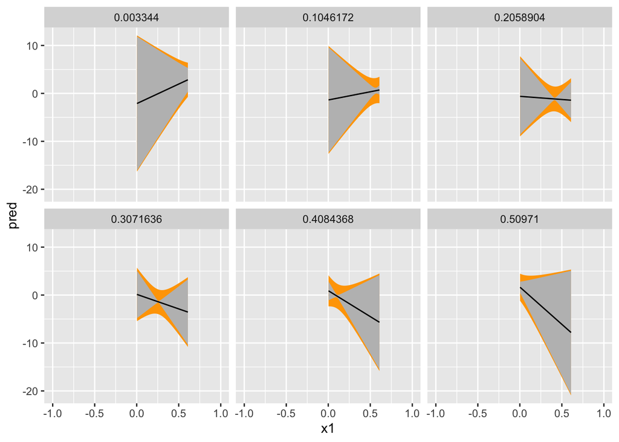

```r
pred_lm_06 <- tidy_predict(mod06,viz_grid_lm)
pred_lm_06 %>% ggplot( mapping = aes(x = x1)) + geom_ribbon( mapping = aes(ymin = pred_lwr , ymax = pred_upr), fill = 'orange') + geom_ribbon( mapping = aes( ymin = ci_lwr, ymax = ci_upr), fill = 'grey') + geom_line( mapping = aes(y = pred))  + facet_wrap(~x3) + coord_cartesian((ylim = c(-1,1)))
```

For Bayesian best model : laplace_lm_mod2

```r
generate_lm_post_samples <- function(mvn_result, length_beta, num_samples)
{
  MASS::mvrnorm(n = num_samples,
                mu = mvn_result$mode,
                Sigma = mvn_result$var_matrix) %>%
    as.data.frame() %>% tibble::as_tibble() %>%
    purrr::set_names(c(sprintf("beta_%02d", 0:(length_beta-1)), "varphi")) %>%
    mutate(sigma = exp(varphi))
}
```

```r
post_lm_pred_samples <- function(Xnew, Bmat, sigma_vector)
{
  M <- nrow(Xnew)
  S <- nrow(Bmat)

  Umat <- Xnew %*% t(Bmat)

  Rmat <- matrix(rep(sigma_vector, M), nrow(Xnew) , byrow = TRUE)

  Zmat <- matrix(rnorm(M*S), nrow(Xnew) , byrow = TRUE)

  Ymat <- Umat + Rmat * Zmat

  list(Umat = Umat, Ymat = Ymat)
}
```

```r
make_post_lm_pred <- function(Xnew, post)
{
  Bmat <- post %>% dplyr::select(starts_with("beta")) %>% as.matrix()

  sigma_vector <- post %>% pull(sigma)

  post_lm_pred_samples(Xnew, Bmat, sigma_vector)
}
```

```r
summarize_lm_pred_from_laplace <- function(mvn_result, Xtest, num_samples)
{
  post <- generate_lm_post_samples(mvn_result, ncol(Xtest), num_samples)

  pred_test <- make_post_lm_pred(Xtest, post)

  mu_avg <- rowMeans(pred_test$Umat)
  y_avg <- rowMeans(pred_test$Ymat)

  mu_lwr <- apply(pred_test$Umat, 1, stats::quantile, probs = 0.025)
  mu_upr <- apply(pred_test$Umat, 1, stats::quantile, probs = 0.975)
  y_lwr <- apply(pred_test$Ymat, 1, stats::quantile, probs = 0.025)
  y_upr <- apply(pred_test$Ymat, 1, stats::quantile, probs = 0.975)

  tibble::tibble(
    mu_avg = mu_avg,
    mu_lwr = mu_lwr,
    mu_upr = mu_upr,
    y_avg = y_avg,
    y_lwr = y_lwr,
    y_upr = y_upr
  ) %>%
    tibble::rowid_to_column("pred_id")
}
```

```r
bayes_best <- model.matrix( ~ (x1  + x3 + x4 + v2 + v3 + v4 + v5 + w + z + t + x5)^2 , data = viz_grid_lm)
```

```r
post_pred_summary_bayes_best  <- summarize_lm_pred_from_laplace(laplace_lm_mod2, bayes_best, 5000)
```

```r
viz_grid_lm
```

```
## # A tibble: 606 × 11
##         x1      x3     x4    v2    v3    v4    v5     w     z     t    x5
##      <dbl>   <dbl>  <dbl> <dbl> <dbl> <dbl> <dbl> <dbl> <dbl> <dbl> <dbl>
##  1 0.00312 0.00334 0.0558 0.515  5.63 0.489  6.50 0.537  1.96  2.36 0.186
##  2 0.00918 0.00334 0.0558 0.515  5.63 0.489  6.50 0.537  1.96  2.36 0.186
##  3 0.0152  0.00334 0.0558 0.515  5.63 0.489  6.50 0.537  1.96  2.36 0.186
##  4 0.0213  0.00334 0.0558 0.515  5.63 0.489  6.50 0.537  1.96  2.36 0.186
##  5 0.0274  0.00334 0.0558 0.515  5.63 0.489  6.50 0.537  1.96  2.36 0.186
##  6 0.0334  0.00334 0.0558 0.515  5.63 0.489  6.50 0.537  1.96  2.36 0.186
##  7 0.0395  0.00334 0.0558 0.515  5.63 0.489  6.50 0.537  1.96  2.36 0.186
##  8 0.0455  0.00334 0.0558 0.515  5.63 0.489  6.50 0.537  1.96  2.36 0.186
##  9 0.0516  0.00334 0.0558 0.515  5.63 0.489  6.50 0.537  1.96  2.36 0.186
## 10 0.0577  0.00334 0.0558 0.515  5.63 0.489  6.50 0.537  1.96  2.36 0.186
## # … with 596 more rows
```

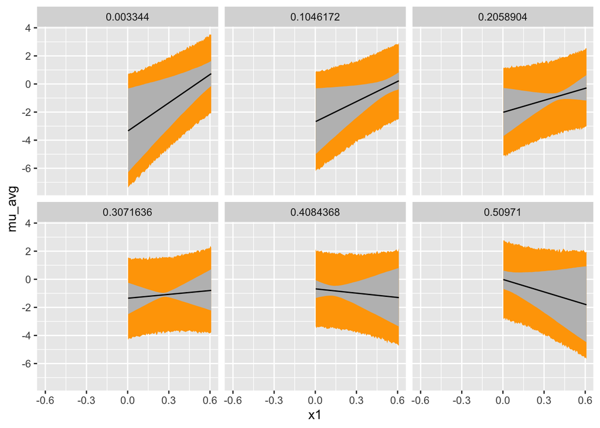

```r
post_pred_summary_bayes_best %>%
  left_join(viz_grid_lm %>% tibble::rowid_to_column("pred_id"),
            by = 'pred_id') %>%
   ggplot(mapping = aes(x = x1)) +
  geom_ribbon( mapping = aes(ymin = y_lwr , ymax = y_upr), fill = 'orange') + geom_ribbon( mapping = aes( ymin = mu_lwr, ymax = mu_upr), fill = 'grey') + geom_line( mapping = aes(y = mu_avg))  +
  facet_wrap(~x3) +
  coord_cartesian((ylim = c(-0.6,0.6)))
```

Analysis of prediction intervals: The prediction and confidence intervals are different in both cases. In one case the confidence interval is wider than the other.